# Using simulation to estimate uncertainty and power

Or how I learned how to stop worrying and love the bootstrap

Authors

Phillip Alday

Reinhold Kliegl

Published

2026-08-23

After working through this page you will be able to:

- use simulation and the parametric bootstrap to estimate power and uncertainty;
- simulate data from scratch for a planned design;
- interpret the simulated distributions to inform design decisions.

**NoteBefore you start**

**Prerequisites:** Parametric bootstrap for mixed-effects models.

**Datasets used:** simulated data only.

```julia
using AlgebraOfGraphics
using CairoMakie
using DataFrames
using Distributions
using MixedModels
using MixedModelsMakie
using MixedModelsSim
using StatsBase
using Random

const progress = isinteractive()
```

# 1 From bootstrap to power analysis

In the parametric bootstrap, we used the parameter estimates from a model fitted to *observed* data to simulate new data and quantify the uncertainty of those estimates. The same machinery – simulate, refit, repeat – also answers a design question: if the true effects had a particular size, how often would we detect them? That is a power analysis. All we need beyond the bootstrap is a way to construct a model object for a design we have not yet run and a way to specify the “true” parameter values that generate the simulated data.

Looking at the docstring for `parametricbootstrap`, we see that there are keyword-arguments for the various model parameters:

```julia
@doc parametricbootstrap
```

```
parametricbootstrap([rng::AbstractRNG], nsamp::Integer, m::MixedModel{T}, ftype=T;
    β = fixef(m), σ = m.σ, θ = m.θ, progress=true, optsum_overrides=(;))
```

Perform `nsamp` parametric bootstrap replication fits of `m`, returning a `MixedModelBootstrap`.

The default random number generator is `Random.GLOBAL_RNG`.

`ftype` can be used to store the computed bootstrap values in a lower precision. `ftype` is not a named argument because named arguments are not used in method dispatch and thus specialization. In other words, having `ftype` as a positional argument has some potential performance benefits.

Keyword Arguments

- `β`, `σ`, and `θ` are the values of `m`'s parameters for simulating the responses.

- `σ` is only valid for `LinearMixedModel` and `GeneralizedLinearMixedModel` for

families with a dispersion parameter.

- `progress` controls whether the progress bar is shown. Note that the progress

bar is automatically disabled for non-interactive (i.e. logging) contexts.

- `optsum_overrides` is used to override values of OptSummary in the models

fit during the bootstrapping process. For example, `optsum_overrides=(;ftol_rel=1e-08)` reduces the convergence criterion, which can greatly speed up the bootstrap fits. Taking advantage of this speed up to increase `n` can often lead to better estimates of coverage intervals.

Note

All coefficients are bootstrapped. In the rank deficient case, the inestimatable coefficients are treated as -0.0 in the simulations underlying the bootstrap, which will generally result in their estimate from the simulated data also being being inestimable and thus set to -0.0. **However this behavior may change in future releases to explicitly drop the extraneous columns before simulation and thus not include their estimates in the bootstrap result.**

These keyword arguments are forward on to the `simulate!` function, which simulates a new dataset based on model matrices and parameter values. The model matrices are simply taken from the model at hand. By default, the parameter values are the estimated parameter values from a fitted model.

```julia
@doc simulate!
```

```
simulate!(rng::AbstractRNG, m::MixedModel{T}; β=fixef(m), σ=m.σ, θ=T[])
simulate!(m::MixedModel; β=fixef(m), σ=m.σ, θ=m.θ)
```

Overwrite the response (i.e. `m.trms[end]`) with a simulated response vector from model `m`.

This simulation includes sampling new values for the random effects.

`β` can be specified either as a pivoted, full rank coefficient vector (cf. `fixef`) or as an unpivoted full dimension coefficient vector (cf. `coef`), where the entries corresponding to redundant columns will be ignored.

Note

Note that `simulate!` methods with a `y::AbstractVector` as the first argument (besides the RNG) and `simulate` methods return the simulated response. This is in contrast to `simulate!` methods with a `m::MixedModel` as the first argument, which modify the model's response and return the entire modified model.

```
simulate!([rng::AbstractRNG,] y::AbstractVector, m::MixedModel{T}[, newdata];
                β = coef(m), σ = m.σ, θ = T[], wts=m.wts)
simulate([rng::AbstractRNG,] m::MixedModel{T}[, newdata];
                β = coef(m), σ = m.σ, θ = T[], wts=m.wts)
```

Simulate a new response vector, optionally overwriting a pre-allocated vector.

New data can be optionally provided in tabular format.

This simulation includes sampling new values for the random effects. Thus in contrast to `predict`, there is no distinction in between "new" and "old" / previously observed random-effects levels.

Unlike `predict`, there is no `type` parameter for `GeneralizedLinearMixedModel` because the noise term in the model and simulation is always on the response scale.

The `wts` argument is currently ignored except for `GeneralizedLinearMixedModel` models with a `Binomial` distribution.

Note

Note that `simulate!` methods with a `y::AbstractVector` as the first argument (besides the RNG) and `simulate` methods return the simulated response. This is in contrast to `simulate!` methods with a `m::MixedModel` as the first argument, which modify the model's response and return the entire modified model.

So now we have a way to simulate new data with new parameter values once we have a model. We just need a way to create a model with our preferred design. We’ll use the MixedModelsSim package for that.

## 1.1 Simulating data from scratch.

The MixedModelsSim package provides a function `simdat_crossed` for simulating effects from a crossed design:

```julia
@doc simdat_crossed
```

```
simdat_crossed([RNG], subj_n, item_n;
               subj_btwn=nothing, item_btwn=nothing, both_win=nothing,
               subj_prefix="S", item_prefix="I")
```

Return a row table with a design specified by the:

- number of subjects (`subj_n`),

- number of items (`item_n`)

- between-subject factors (`subj_btwn`)

- between-item factors (`item_btwn`)

- within-subject/item factors (`both_win`)

If a factor is both between-subject and between-item, put it in both `subj_btwn` and `item_btwn` with the same keys and the same levels.

Factors should be specified as dictionaries in the following format:

```
Dict(
    :factor1_name => ["F1_level1", "F1_level2"],
    :factor2_name => ["F2_level1", "F2_level2", "F2_level3"]
)
```

In addition to design, the rowtable contains a field `dv` pre-populated with N(0,1) noise as a basis for further simulating a design.

Note

Let’s see what that looks like in practice. We’ll look at a simple 2 x 2 design with 20 subjects and 20 items. Our first factor `age` will vary between subjects and have the levels `old` and `young`. Our second factor `frequency` will vary between items and have the levels `low` and `high`. Finally, we also need to specify a random number generator to use for seeding the data simulation.

```julia
subj_n = 20
item_n = 20
subj_btwn = Dict(:age => ["old", "young"])
item_btwn = Dict(:frequency => ["low", "high"])
const RNG = MersenneTwister(42)
dat = simdat_crossed(RNG, subj_n, item_n;
                     subj_btwn, item_btwn)
Table(dat)
```

```
Table with 5 columns and 400 rows:
      subj  age    item  frequency  dv
    ┌─────────────────────────────────────────
 1  │ S01   old    I01   low        1.21028
 2  │ S02   young  I01   low        -0.0789986
 3  │ S03   old    I01   low        0.403512
 4  │ S04   young  I01   low        0.289951
 5  │ S05   old    I01   low        -0.0670422
 6  │ S06   young  I01   low        0.61398
 7  │ S07   old    I01   low        1.01694
 8  │ S08   young  I01   low        -0.053864
 9  │ S09   old    I01   low        -0.570387
 10 │ S10   young  I01   low        -0.857737
 11 │ S11   old    I01   low        -0.211452
 12 │ S12   young  I01   low        -0.853673
 13 │ S13   old    I01   low        0.439568
 14 │ S14   young  I01   low        -1.31491
 15 │ S15   old    I01   low        0.176901
 16 │ S16   young  I01   low        -0.254805
 17 │ S17   old    I01   low        -1.77737
 ⋮  │  ⋮      ⋮     ⋮        ⋮          ⋮
```

We have 400 rows – 20 subjects x 20 items. Similarly, the experimental factors are expanded out to be fully crossed. Finally, we have a dependent variable `dv` initialized to be draws from the standard normal distribution $N(0,1)$.

**NoteLatin squares, partial crossing, and continuous covariates**

`simdat_crossed` is designed to simulate a fully crossed factorial design. If you have a partially crossed or Latin squares design, then you could delete the “extra” cells to reduce the fully crossed data here to be partially crossed. For continuous covariates, we need to separately construct the covariates and then use a tabular join to create the design. We’ll examine an example of this later.

```julia
simmod = fit(MixedModel,
             @formula(dv ~ 1 + age * frequency +
                          (1 + frequency | subj) +
                          (1 + age | item)), dat; progress)
println(simmod)
```

```
Linear mixed model fit by maximum likelihood
 dv ~ 1 + age + frequency + age & frequency + (1 + frequency | subj) + (1 + age | item)
   logLik   -2 logLik     AIC       AICc        BIC
  -591.8575  1183.7149  1205.7149  1206.3953  1249.6210

Variance components:
             Column      Variance  Std.Dev.   Corr.
subj     (Intercept)     0.0733656 0.2708608
         frequency: low  0.0335313 0.1831157 -1.00
item     (Intercept)     0.0132766 0.1152241
         age: young      0.0005200 0.0228031 -1.00
Residual                 1.0883091 1.0432205
 Number of obs: 400; levels of grouping factors: 20, 20

  Fixed-effects parameters:
─────────────────────────────────────────────────────────────────────
                                   Coef.  Std. Error      z  Pr(>|z|)
─────────────────────────────────────────────────────────────────────
(Intercept)                   0.0816111     0.139812   0.58    0.5594
age: young                   -0.0349801     0.191027  -0.18    0.8547
frequency: low               -0.0638793     0.166657  -0.38    0.7015
age: young & frequency: low   0.00879841    0.224372   0.04    0.9687
─────────────────────────────────────────────────────────────────────
```

```julia
β = [250.0, -25.0, 10, 0.0]
simulate!(RNG, simmod; β)
```

|  | Est. | SE | z | p | σ_subj | σ_item |
| --- | --- | --- | --- | --- | --- | --- |
| (Intercept) | 0.0816 | 0.1398 | 0.58 | 0.5594 | 0.2709 | 0.1152 |
| age: young | -0.0350 | 0.1910 | -0.18 | 0.8547 |  | 0.0228 |
| frequency: low | -0.0639 | 0.1667 | -0.38 | 0.7015 | 0.1831 |  |
| age: young & frequency: low | 0.0088 | 0.2244 | 0.04 | 0.9687 |  |  |
| Residual | 1.0432 |  |  |  |  |  |

```julia
fit!(simmod)
```

|  | Est. | SE | z | p | σ_subj | σ_item |
| --- | --- | --- | --- | --- | --- | --- |
| (Intercept) | 249.9796 | 0.1267 | 1973.16 | <1e-99 | 0.1641 | 0.1703 |
| age: young | -25.0472 | 0.1655 | -151.36 | <1e-99 |  | 0.1041 |
| frequency: low | 9.7387 | 0.1640 | 59.39 | <1e-99 | 0.0422 |  |
| age: young & frequency: low | 0.1164 | 0.2106 | 0.55 | 0.5804 |  |  |
| Residual | 1.0225 |  |  |  |  |  |

```julia
σ = 25.0
fit!(simulate!(RNG, simmod; β, σ))
```

|  | Est. | SE | z | p | σ_subj | σ_item |
| --- | --- | --- | --- | --- | --- | --- |
| (Intercept) | 256.2394 | 3.9124 | 65.49 | <1e-99 | 4.5684 | 8.6530 |
| age: young | -33.8588 | 4.6177 | -7.33 | <1e-12 |  | 7.5397 |
| frequency: low | 5.5490 | 5.2227 | 1.06 | 0.2880 | 2.8944 |  |
| age: young & frequency: low | 5.1727 | 5.9978 | 0.86 | 0.3884 |  |  |
| Residual | 23.9420 |  |  |  |  |  |

```julia
# relative to σ!
subj_re = create_re(2.0, 1.3)
```

```
2×2 LinearAlgebra.LowerTriangular{Float64, LinearAlgebra.Diagonal{Float64, Vector{Float64}}}:
 2.0   ⋅
 0.0  1.3
```

```julia
item_re = create_re(1.3, 2.0)
```

```
2×2 LinearAlgebra.LowerTriangular{Float64, LinearAlgebra.Diagonal{Float64, Vector{Float64}}}:
 1.3   ⋅
 0.0  2.0
```

```julia
θ = createθ(simmod; subj=subj_re, item=item_re)
```

```
6-element Vector{Float64}:
 2.0
 0.0
 1.3
 1.3
 0.0
 2.0
```

```julia
fit!(simulate!(RNG, simmod; β, σ, θ))
```

|  | Est. | SE | z | p | σ_subj | σ_item |
| --- | --- | --- | --- | --- | --- | --- |
| (Intercept) | 238.6765 | 15.4590 | 15.44 | <1e-53 | 39.9114 | 27.0075 |
| age: young | -21.2541 | 21.2976 | -1.00 | 0.3183 |  | 34.8575 |
| frequency: low | -0.3036 | 16.0265 | -0.02 | 0.9849 | 31.2202 |  |
| age: young & frequency: low | 16.0378 | 21.5626 | 0.74 | 0.4570 |  |  |
| Residual | 25.9787 |  |  |  |  |  |

```julia
samp = parametricbootstrap(RNG, 1000, simmod; β, σ, θ, progress)
```

```
MixedModelBootstrap with 1000 samples
      parameter  min        q25        median      mean        q75       ⋯
    ┌─────────────────────────────────────────────────────────────────────
 1  │ β1         187.504    236.563    250.196     249.917     263.367   ⋯
 2  │ β2         -118.074   -45.386    -24.2367    -25.4062    -6.48009  ⋯
 3  │ β3         -57.7974   -2.0594    8.93123     9.78849     22.555    ⋯
 4  │ β4         -77.082    -17.5927   0.253178    -0.0776182  17.2086   ⋯
 5  │ σ          22.204     24.3262    24.9756     24.9547     25.5221   ⋯
 6  │ σ1         25.6549    42.027     47.4457     47.7116     53.3682   ⋯
 7  │ σ2         13.7514    26.8112    31.2347     30.9942     34.9932   ⋯
 8  │ ρ1         -0.808928  -0.18075   -0.0242876  -0.0201442  0.151477  ⋯
 9  │ σ3         14.4239    27.508     31.2277     31.2821     35.1992   ⋯
 10 │ σ4         17.287     42.1595    47.4245     47.5599     52.6321   ⋯
 11 │ ρ2         -0.696028  -0.203852  -0.0184107  -0.0147826  0.156928  ⋯
 12 │ θ1         1.01087    1.68976    1.90887     1.91418     2.13819   ⋯
 13 │ θ2         -1.19827   -0.227775  -0.0266265  -0.0274248  0.185927  ⋯
 14 │ θ3         0.369048   1.03083    1.20271     1.20325     1.37222   ⋯
 15 │ θ4         0.570767   1.09377    1.24564     1.25551     1.40709   ⋯
 16 │ θ5         -1.32032   -0.386843  -0.0346073  -0.0343756  0.302657  ⋯
 17 │ θ6         0.683923   1.62089    1.84137     1.84508     2.0708    ⋯
```

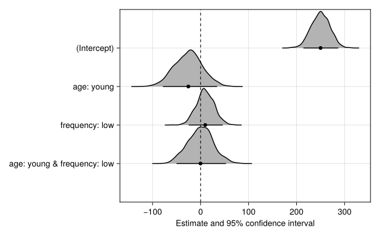

```julia
ridgeplot(samp)
```

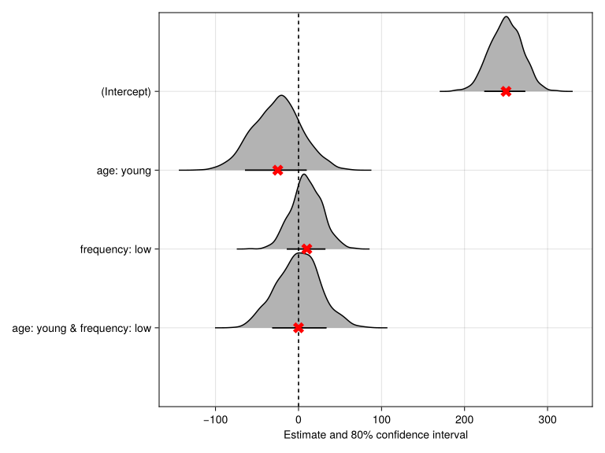

```julia
let f = Figure()
    ax = Axis(f[1, 1])
    coefplot!(ax, samp;
              conf_level=0.8,
              vline_at_zero=true,
              show_intercept=true)
    ridgeplot!(ax, samp;
               conf_level=0.8,
               vline_at_zero=true,
               show_intercept=true,
#               xlabel="Normalized density and 80% range")
    )
    scatter!(ax, β, length(β):-1:1;
             marker=:x,
             markersize=20,
             color=:red)
    f
end
```

```julia
coefpvalues = DataFrame()
# @showprogress
for subj_n in [20, 40, 60, 80, 100, 120, 140],  item_n in [40, 60, 80, 100, 120, 140]
    dat = simdat_crossed(RNG, subj_n, item_n;
                         subj_btwn, item_btwn)
    simmod = MixedModel(@formula(dv ~ 1 + age * frequency +
                                     (1 + frequency | subj) +
                                     (1 + age | item)),
                        dat)

    θ = createθ(simmod; subj=subj_re, item=item_re)
    # optsum_overrides speeds up the replicate fits;
    # see the reduced-precision note on the bootstrap page
    simboot = parametricbootstrap(RNG, 100, simmod;
                                  β, σ, θ,
                                  optsum_overrides=(;ftol_rel=1e-8),
                                  progress)
    df = DataFrame(simboot.coefpvalues)
    df[!, :subj_n] .= subj_n
    df[!, :item_n] .= item_n
    append!(coefpvalues, df)
end
```

```julia
power = combine(groupby(coefpvalues, [:coefname, :subj_n, :item_n]),
                :p => (p -> mean(p .< 0.05)) => :power)
```

168×4 DataFrame

143 rows omitted

| Row | coefname Symbol | subj_n Int64 | item_n Int64 | power Float64 |
| --- | --- | --- | --- | --- |
| 1 | (Intercept) | 20 | 40 | 1.0 |
| 2 | age: young | 20 | 40 | 0.29 |
| 3 | frequency: low | 20 | 40 | 0.07 |
| 4 | age: young & frequency: low | 20 | 40 | 0.06 |
| 5 | (Intercept) | 20 | 60 | 1.0 |
| 6 | age: young | 20 | 60 | 0.21 |
| 7 | frequency: low | 20 | 60 | 0.17 |
| 8 | age: young & frequency: low | 20 | 60 | 0.04 |
| 9 | (Intercept) | 20 | 80 | 1.0 |
| 10 | age: young | 20 | 80 | 0.15 |
| 11 | frequency: low | 20 | 80 | 0.17 |
| 12 | age: young & frequency: low | 20 | 80 | 0.07 |
| 13 | (Intercept) | 20 | 100 | 1.0 |
| ⋮ | ⋮ | ⋮ | ⋮ | ⋮ |
| 157 | (Intercept) | 140 | 100 | 1.0 |
| 158 | age: young | 140 | 100 | 0.59 |
| 159 | frequency: low | 140 | 100 | 0.21 |
| 160 | age: young & frequency: low | 140 | 100 | 0.04 |
| 161 | (Intercept) | 140 | 120 | 1.0 |
| 162 | age: young | 140 | 120 | 0.71 |
| 163 | frequency: low | 140 | 120 | 0.35 |
| 164 | age: young & frequency: low | 140 | 120 | 0.05 |
| 165 | (Intercept) | 140 | 140 | 1.0 |
| 166 | age: young | 140 | 140 | 0.62 |
| 167 | frequency: low | 140 | 140 | 0.3 |
| 168 | age: young & frequency: low | 140 | 140 | 0.03 |

```julia
power = combine(groupby(coefpvalues,
                        [:coefname, :subj_n, :item_n]),
                :p => (p -> mean(p .< 0.05)) => :power,
                :p => (p -> sem(p .< 0.05)) => :power_se)
```

168×5 DataFrame

143 rows omitted

| Row | coefname Symbol | subj_n Int64 | item_n Int64 | power Float64 | power_se Float64 |
| --- | --- | --- | --- | --- | --- |
| 1 | (Intercept) | 20 | 40 | 1.0 | 0.0 |
| 2 | age: young | 20 | 40 | 0.29 | 0.0456048 |
| 3 | frequency: low | 20 | 40 | 0.07 | 0.0256432 |
| 4 | age: young & frequency: low | 20 | 40 | 0.06 | 0.0238683 |
| 5 | (Intercept) | 20 | 60 | 1.0 | 0.0 |
| 6 | age: young | 20 | 60 | 0.21 | 0.040936 |
| 7 | frequency: low | 20 | 60 | 0.17 | 0.0377525 |
| 8 | age: young & frequency: low | 20 | 60 | 0.04 | 0.0196946 |
| 9 | (Intercept) | 20 | 80 | 1.0 | 0.0 |
| 10 | age: young | 20 | 80 | 0.15 | 0.035887 |
| 11 | frequency: low | 20 | 80 | 0.17 | 0.0377525 |
| 12 | age: young & frequency: low | 20 | 80 | 0.07 | 0.0256432 |
| 13 | (Intercept) | 20 | 100 | 1.0 | 0.0 |
| ⋮ | ⋮ | ⋮ | ⋮ | ⋮ | ⋮ |
| 157 | (Intercept) | 140 | 100 | 1.0 | 0.0 |
| 158 | age: young | 140 | 100 | 0.59 | 0.0494311 |
| 159 | frequency: low | 140 | 100 | 0.21 | 0.040936 |
| 160 | age: young & frequency: low | 140 | 100 | 0.04 | 0.0196946 |
| 161 | (Intercept) | 140 | 120 | 1.0 | 0.0 |
| 162 | age: young | 140 | 120 | 0.71 | 0.0456048 |
| 163 | frequency: low | 140 | 120 | 0.35 | 0.0479372 |
| 164 | age: young & frequency: low | 140 | 120 | 0.05 | 0.0219043 |
| 165 | (Intercept) | 140 | 140 | 1.0 | 0.0 |
| 166 | age: young | 140 | 140 | 0.62 | 0.0487832 |
| 167 | frequency: low | 140 | 140 | 0.3 | 0.0460566 |
| 168 | age: young & frequency: low | 140 | 140 | 0.03 | 0.0171447 |

```julia
select!(power, :coefname, :subj_n, :item_n, :power,
        [:power, :power_se] => ByRow((p, se) -> [p - 1.96*se, p + 1.96*se]) => [:lower, :upper])
```

168×6 DataFrame

143 rows omitted

| Row | coefname Symbol | subj_n Int64 | item_n Int64 | power Float64 | lower Float64 | upper Float64 |
| --- | --- | --- | --- | --- | --- | --- |
| 1 | (Intercept) | 20 | 40 | 1.0 | 1.0 | 1.0 |
| 2 | age: young | 20 | 40 | 0.29 | 0.200615 | 0.379385 |
| 3 | frequency: low | 20 | 40 | 0.07 | 0.0197392 | 0.120261 |
| 4 | age: young & frequency: low | 20 | 40 | 0.06 | 0.0132181 | 0.106782 |
| 5 | (Intercept) | 20 | 60 | 1.0 | 1.0 | 1.0 |
| 6 | age: young | 20 | 60 | 0.21 | 0.129765 | 0.290235 |
| 7 | frequency: low | 20 | 60 | 0.17 | 0.0960051 | 0.243995 |
| 8 | age: young & frequency: low | 20 | 60 | 0.04 | 0.00139851 | 0.0786015 |
| 9 | (Intercept) | 20 | 80 | 1.0 | 1.0 | 1.0 |
| 10 | age: young | 20 | 80 | 0.15 | 0.0796614 | 0.220339 |
| 11 | frequency: low | 20 | 80 | 0.17 | 0.0960051 | 0.243995 |
| 12 | age: young & frequency: low | 20 | 80 | 0.07 | 0.0197392 | 0.120261 |
| 13 | (Intercept) | 20 | 100 | 1.0 | 1.0 | 1.0 |
| ⋮ | ⋮ | ⋮ | ⋮ | ⋮ | ⋮ | ⋮ |
| 157 | (Intercept) | 140 | 100 | 1.0 | 1.0 | 1.0 |
| 158 | age: young | 140 | 100 | 0.59 | 0.493115 | 0.686885 |
| 159 | frequency: low | 140 | 100 | 0.21 | 0.129765 | 0.290235 |
| 160 | age: young & frequency: low | 140 | 100 | 0.04 | 0.00139851 | 0.0786015 |
| 161 | (Intercept) | 140 | 120 | 1.0 | 1.0 | 1.0 |
| 162 | age: young | 140 | 120 | 0.71 | 0.620615 | 0.799385 |
| 163 | frequency: low | 140 | 120 | 0.35 | 0.256043 | 0.443957 |
| 164 | age: young & frequency: low | 140 | 120 | 0.05 | 0.00706759 | 0.0929324 |
| 165 | (Intercept) | 140 | 140 | 1.0 | 1.0 | 1.0 |
| 166 | age: young | 140 | 140 | 0.62 | 0.524385 | 0.715615 |
| 167 | frequency: low | 140 | 140 | 0.3 | 0.209729 | 0.390271 |
| 168 | age: young & frequency: low | 140 | 140 | 0.03 | -0.00360354 | 0.0636035 |

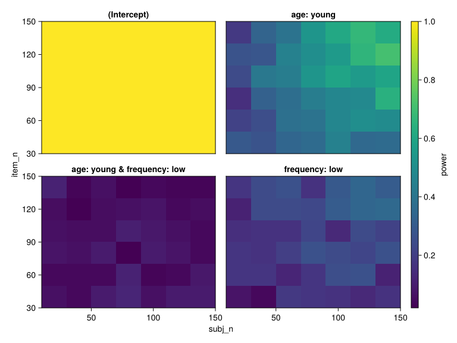

```julia
data(power) * mapping(:subj_n, :item_n, :power; layout=:coefname) * visual(Heatmap) |> draw
```

```julia
dat = simdat_crossed(RNG, subj_n, item_n;
                     subj_btwn, item_btwn)
dat = DataFrame(dat)
```

400×5 DataFrame

375 rows omitted

| Row | subj String | age String | item String | frequency String | dv Float64 |
| --- | --- | --- | --- | --- | --- |
| 1 | S01 | old | I01 | low | -0.882085 |
| 2 | S02 | young | I01 | low | -0.0201484 |
| 3 | S03 | old | I01 | low | 0.945484 |
| 4 | S04 | young | I01 | low | -0.247553 |
| 5 | S05 | old | I01 | low | 0.453218 |
| 6 | S06 | young | I01 | low | 0.924281 |
| 7 | S07 | old | I01 | low | 0.220375 |
| 8 | S08 | young | I01 | low | 1.85978 |
| 9 | S09 | old | I01 | low | -0.44618 |
| 10 | S10 | young | I01 | low | -0.754939 |
| 11 | S11 | old | I01 | low | 0.0105376 |
| 12 | S12 | young | I01 | low | 0.929521 |
| 13 | S13 | old | I01 | low | -0.314341 |
| ⋮ | ⋮ | ⋮ | ⋮ | ⋮ | ⋮ |
| 389 | S09 | old | I20 | high | 2.2703 |
| 390 | S10 | young | I20 | high | -0.00613232 |
| 391 | S11 | old | I20 | high | -0.923031 |
| 392 | S12 | young | I20 | high | 0.539303 |
| 393 | S13 | old | I20 | high | -0.868366 |
| 394 | S14 | young | I20 | high | 2.10268 |
| 395 | S15 | old | I20 | high | -1.23199 |
| 396 | S16 | young | I20 | high | -1.02512 |
| 397 | S17 | old | I20 | high | 0.818806 |
| 398 | S18 | young | I20 | high | 1.7468 |
| 399 | S19 | old | I20 | high | -0.327621 |
| 400 | S20 | young | I20 | high | -0.841135 |

```julia
item_covariates = unique!(select(dat, :item))
```

20×1 DataFrame

| Row | item String |
| --- | --- |
| 1 | I01 |
| 2 | I02 |
| 3 | I03 |
| 4 | I04 |
| 5 | I05 |
| 6 | I06 |
| 7 | I07 |
| 8 | I08 |
| 9 | I09 |
| 10 | I10 |
| 11 | I11 |
| 12 | I12 |
| 13 | I13 |
| 14 | I14 |
| 15 | I15 |
| 16 | I16 |
| 17 | I17 |
| 18 | I18 |
| 19 | I19 |
| 20 | I20 |

```julia
item_covariates[!, :chaos] = rand(RNG,
                                  Normal(5, 2),
                                  nrow(item_covariates))
```

```
20-element Vector{Float64}:
 4.283869606409811
 1.766354546694887
 3.5819077117990936
 4.426082794175044
 3.979161685431401
 4.150057335954468
 5.209549095470591
 5.3931183588041325
 5.836973833266723
 6.042800312594512
 3.1607596007727814
 6.519844952694776
 9.286581793894484
 7.995006071550052
 4.189786264631877
 2.4169512074675787
 3.445736901440534
 5.123574599692554
 4.422113183811228
 1.9739443958799194
```

```julia
leftjoin!(dat, item_covariates; on=:item)
```

400×6 DataFrame

375 rows omitted

| Row | subj String | age String | item String | frequency String | dv Float64 | chaos Float64? |
| --- | --- | --- | --- | --- | --- | --- |
| 1 | S01 | old | I01 | low | -0.882085 | 4.28387 |
| 2 | S02 | young | I01 | low | -0.0201484 | 4.28387 |
| 3 | S03 | old | I01 | low | 0.945484 | 4.28387 |
| 4 | S04 | young | I01 | low | -0.247553 | 4.28387 |
| 5 | S05 | old | I01 | low | 0.453218 | 4.28387 |
| 6 | S06 | young | I01 | low | 0.924281 | 4.28387 |
| 7 | S07 | old | I01 | low | 0.220375 | 4.28387 |
| 8 | S08 | young | I01 | low | 1.85978 | 4.28387 |
| 9 | S09 | old | I01 | low | -0.44618 | 4.28387 |
| 10 | S10 | young | I01 | low | -0.754939 | 4.28387 |
| 11 | S11 | old | I01 | low | 0.0105376 | 4.28387 |
| 12 | S12 | young | I01 | low | 0.929521 | 4.28387 |
| 13 | S13 | old | I01 | low | -0.314341 | 4.28387 |
| ⋮ | ⋮ | ⋮ | ⋮ | ⋮ | ⋮ | ⋮ |
| 389 | S09 | old | I20 | high | 2.2703 | 1.97394 |
| 390 | S10 | young | I20 | high | -0.00613232 | 1.97394 |
| 391 | S11 | old | I20 | high | -0.923031 | 1.97394 |
| 392 | S12 | young | I20 | high | 0.539303 | 1.97394 |
| 393 | S13 | old | I20 | high | -0.868366 | 1.97394 |
| 394 | S14 | young | I20 | high | 2.10268 | 1.97394 |
| 395 | S15 | old | I20 | high | -1.23199 | 1.97394 |
| 396 | S16 | young | I20 | high | -1.02512 | 1.97394 |
| 397 | S17 | old | I20 | high | 0.818806 | 1.97394 |
| 398 | S18 | young | I20 | high | 1.7468 | 1.97394 |
| 399 | S19 | old | I20 | high | -0.327621 | 1.97394 |
| 400 | S20 | young | I20 | high | -0.841135 | 1.97394 |

```julia
simmod = fit(MixedModel,
             @formula(dv ~ 1 + age * frequency * chaos +
                          (1 + frequency | subj) +
                          (1 + age | item)), dat; progress)
```

|  | Est. | SE | z | p | σ_subj | σ_item |
| --- | --- | --- | --- | --- | --- | --- |
| (Intercept) | 0.0560 | 0.2412 | 0.23 | 0.8164 | 0.0000 | 0.0000 |
| age: young | -0.3565 | 0.3411 | -1.05 | 0.2959 |  | 0.0000 |
| frequency: low | 0.0548 | 0.3699 | 0.15 | 0.8822 | 0.0000 |  |
| chaos | -0.0135 | 0.0484 | -0.28 | 0.7809 |  |  |
| age: young & frequency: low | 0.1030 | 0.5232 | 0.20 | 0.8439 |  |  |
| age: young & chaos | 0.1036 | 0.0685 | 1.51 | 0.1305 |  |  |
| frequency: low & chaos | -0.0421 | 0.0738 | -0.57 | 0.5683 |  |  |
| age: young & frequency: low & chaos | -0.0317 | 0.1044 | -0.30 | 0.7617 |  |  |
| Residual | 0.9456 |  |  |  |  |  |

```julia
dat[!, :dv] = rand(RNG, Bernoulli(), nrow(dat))
```

```
400-element Vector{Bool}:
 0
 1
 0
 0
 1
 1
 1
 0
 0
 0
 ⋮
 1
 1
 1
 0
 1
 1
 0
 0
 1
```

```julia
dat[!, :dv] = rand(RNG, Poisson(), nrow(dat))
```

```
400-element Vector{Int64}:
 2
 1
 2
 0
 0
 1
 0
 2
 0
 1
 ⋮
 0
 2
 0
 1
 1
 3
 0
 1
 1
```

```julia
dat[!, :n] = rand(RNG, Poisson(), nrow(dat)) .+ 3
```

```
400-element Vector{Int64}:
 5
 3
 3
 7
 4
 3
 5
 3
 3
 4
 ⋮
 4
 3
 3
 4
 4
 3
 6
 4
 3
```

```julia
dat[!, :dv] = rand.(RNG, Binomial.(dat[!, :n])) ./ dat[!, :n]
```

```
400-element Vector{Float64}:
 0.6
 0.3333333333333333
 0.6666666666666666
 0.42857142857142855
 0.5
 0.6666666666666666
 0.2
 0.3333333333333333
 0.6666666666666666
 0.5
 ⋮
 0.5
 0.6666666666666666
 0.3333333333333333
 0.25
 1.0
 1.0
 0.5
 0.75
 1.0
```

## 1.2 Exercises

1. **Effect size and power.** Re-run the simulation across a range of assumed effect sizes, holding the sample size fixed. Plot estimated power against effect size. What shape do you expect?

**NoteSolution**

Power increases monotonically with effect size, tracing an S-shaped curve from the nominal false-positive rate (when the true effect is zero) toward 1 (for large effects). The interesting region is the middle, where small design changes move power the most.

2. **Sample size.** Now hold the effect size fixed and vary the number of subjects. How does required sample size trade off against effect size for a target power (say 0.8)?

**NoteSolution**

For a fixed target power, required sample size grows rapidly as the effect size shrinks (roughly inversely with the square of the effect size). Simulating a grid over both lets you read off feasible design points rather than relying on a single closed-form approximation.

*This page was rendered from git revision [29e8d33](https://github.com/RePsychLing/SMLP2026/tree/29e8d33  
) using Quarto 1.10.18 and Julia 1.12.7.*

Back to top